```python
import requests
from bs4 import BeautifulSoup
from sklearn.preprocessing import StandardScaler
import matplotlib.pyplot as plt
import seaborn as sns
from scipy import stats
import numpy as np
import pandas as pd
from sklearn import datasets, linear_model
from sklearn.metrics import mean_squared_error, r2_score
import math
import scipy.stats as stats
import statsmodels.api as sm
import statistics as st
import sqlite3
```

# Подготовка данных

```python
page = requests.get('https://cbr.ru/currency_base/dynamics/')
contents = page.content
soup = BeautifulSoup(contents, 'html.parser')
a =  soup.find_all("option")

currencies = {}
for i in range(len(a)):
  currencies[a[i].contents[0].strip()] = a[i].get('value')
```

```python
def getCurrencyData(currency, _from, _to):
  page = requests.get('https://cbr.ru/currency_base/dynamics/?UniDbQuery.Posted=True&UniDbQuery.mode=1&UniDbQuery.date_req1=&UniDbQuery.date_req2=&UniDbQuery.VAL_NM_RQ=' + currencies[currency] + "&UniDbQuery.From=" + _from + "&UniDbQuery.To=" + _to)
  soup = BeautifulSoup(page.content, 'html.parser')
  table =  soup.find_all("table")
  if (len(table) == 0): # Если данных нет
    return None
  else:                 # Усли данные нашлись
    th = soup.find_all("th")
    td = soup.find_all("td")
    del td[0] # Удаляем название валюты за ненадобностью
    df = pd.DataFrame(columns=[th[0].contents[0], th[1].contents[0], currency]) # Создали датасет с нужными колонками
    i = 0
    while (i <= len(td)-1): # парсим таблицу
      data= []
      for k in range(3):
        data += td[i:i+3][k].contents
      df.loc[len(df.index)] = [data[0], data[1], data[2]]
      i = i+3

    df[currency] =  df[currency].apply(lambda x : str(x).replace(",", "."))
    df[currency] =  df[currency].astype("float") / df[df.columns[1]].astype("float")
    df[df.columns[1]] = 1
    return df

def getData(date_from, date_to, *args):
  if (len(args) == 1):
    return getCurrencyData(args[0], date_from, date_to)
  else:
    current_df = None
    for arg in range(len(args)):
      tmp = getCurrencyData(args[arg], date_from, date_to)
      if (tmp is None):
        continue
      else:
        if (arg != 0):
          current_df = pd.merge(tmp, current_df, on=["Дата", "Единиц"])
        else:
          current_df = tmp
    return current_df
```

**Доступные на сайте Валюты для выбора**

- Австралийский доллар
- Австрийский шиллинг
- Азербайджанский манат
- Албанский лек
- Алжирский динар
- Ангольская новая кванза
- Аргентинское песо
- Армянский драм
- Афганский афгани
- Бахрейнский динар
- Белорусский рубль
- Бельгийский франк
- Болгарский лев
- Боливийский боливиано
- Ботсванская пула
- Бразильский реал
- Брунейский доллар
- Бурундийский франк
- Венгерский форинт
- Венесуэльский боливар фу
- Вон Республики Корея
- Вона КНДР
- Вьетнамский донг
- Гамбийский даласи
- Ганский седи
- Гвинейский франк
- Гонконгский доллар
- Греческая драхма
- Грузинский лари
- Датская крона
- Дирхам ОАЭ
- Доллар Зимбабве
- Доллар Намибии
- Доллар США
- Евро
- Египетский фунт
- Заир ДРК
- Замбийская квача
- Израильский новый шекель
- Индийская рупия
- Индонезийская рупия
- Иорданский динар
- Иракский динар
- Иранский риал
- Ирландский фунт
- Исландская крона
- Испанская песета
- Итальянская лира
- Йеменский риал
- Казахстанский тенге
- Канадский доллар
- Катарский риал
- Кенийский шиллинг
- Кипрский фунт
- Киргизский сом
- Китайский юань
- Колумбийский песо
- Конголезский франк
- Костариканский колон
- Кубинское песо
- Кувейтский динар
- Лаосский кип
- Латвийский лат
- Леоне Сьерра-Леоне
- Ливанский фунт
- Ливийский динар
- Лилангени Свазиленда
- Литовский лит
- Литовский талон
- Маврикийская рупия
- Мавританская угия
- Македонский динар
- Малавийская квача
- Малагасийский ариари
- Малайзийский ринггит
- Мальтийская лира
- Марокканский дирхам
- Мексиканский песо
- Мозамбикский метикал
- Молдавский лей
- Монгольский тугрик
- Немецкая марка
- Непальская рупия
- Нигерийский найр
- Нидерландский гульден
- Никарагуанская золотая к
- Новозеландский доллар
- Новый туркменский манат
- Норвежская крона
- Оманский риал
- Пакистанская рупия
- Парагвайская гуарани
- Перуанский новый соль
- Польский злотый
- Португальский эскудо
- Риель Камбоджи
- Риял Саудовской Аравии
- Румынский лей
- СДР (специальные права
- Сейшельская рупия
- Сингапурский доллар
- Сирийский фунт
- Словацкая крона
- Словенский толар
- Сомалийский шиллинг
- Суданский фунт
- Суринамский доллар
- Таджикский рубл
- Таджикский сомони
- Таиландский бат
- Тайваньский новый доллар
- Так Бангладеш
- Танзанийский шиллинг
- Тунисский динар
- Турецкая лира
- Туркменский манат
- Угандийский шиллинг
- Узбекский сум
- Украинская гривна
- Украинский карбованец
- Уругвайское песо
- Филиппинское песо
- Финляндская марка
- Франк Джибути
- Франк КФА ВЕАС
- Франк КФА ВСЕАО
- Французский франк
- Фунт стерлингов Соединен
- Хорватская куна
- Чехословацкая крона
- Чешская крона
- Чилийское песо
- Шведская крона
- Швейцарский франк
- Шри-Ланкийская рупия
- ЭКЮ
- Эквадорский сукре
- Эстонская крона
- Эфиопский быр
- Югославский новый динар
- Южноафриканский рэнд
- Японская иена

Пример URL pапроса для данных: https://cbr.ru/currency_base/dynamics/?UniDbQuery.Posted=True&UniDbQuery.mode=1&UniDbQuery.date_req1=&UniDbQuery.date_req2=&UniDbQuery.VAL_NM_RQ=R01010&UniDbQuery.From=10.10.2020&UniDbQuery.To=17.10.2020

# Замените поля следующей ячейки на поля интересующие Вас.

Название валюты выберите из существующего списка выше

```python
data = getData("17.09.2020", "17.10.2020", "Фунт стерлингов Соединен", "Австралийский доллар", "Турецкая лира", "Югославский новый динар")
```

# Работа с SQLlite

```python
conn = sqlite3.connect('Currencies.db')
data.to_sql("table", conn)
```

```python
data = data.drop("Единиц", axis=1)
data = data.set_index("Дата")
data.index = data.index.rename(None)
data.head()
```

|  | Турецкая лира | Австралийский доллар | Фунт стерлингов Соединен |
| --- | --- | --- | --- |
| 17.09.2020 | 10.00020 | 54.9221 | 96.6644 |
| 18.09.2020 | 9.97375 | 54.8842 | 97.3839 |
| 19.09.2020 | 9.92709 | 54.9008 | 97.4439 |
| 22.09.2020 | 10.01080 | 55.3709 | 97.7850 |
| 23.09.2020 | 9.96213 | 54.9228 | 97.7719 |

```python
data.describe()
```

|  | Турецкая лира | Австралийский доллар | Фунт стерлингов Соединен |
| --- | --- | --- | --- |
| count | 23.000000 | 23.000000 | 23.000000 |
| mean | 9.959919 | 55.382483 | 99.673804 |
| std | 0.141471 | 0.598878 | 1.760694 |
| min | 9.711710 | 54.311000 | 96.664400 |
| 25% | 9.827950 | 54.922450 | 97.937900 |
| 50% | 9.973750 | 55.416100 | 100.362100 |
| 75% | 10.080550 | 55.741500 | 101.018450 |
| max | 10.169600 | 56.528200 | 102.609700 |

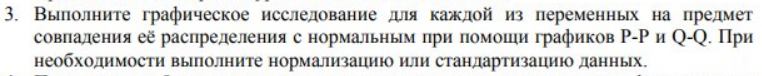

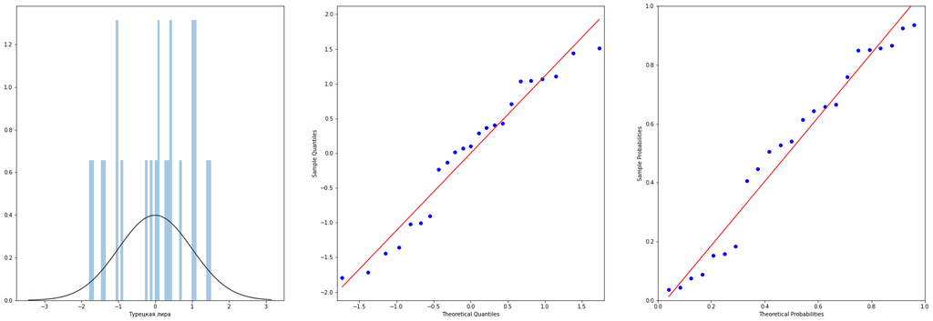

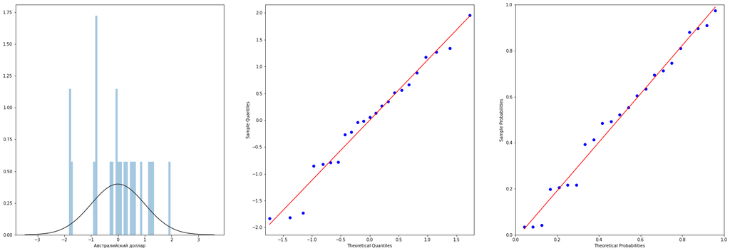

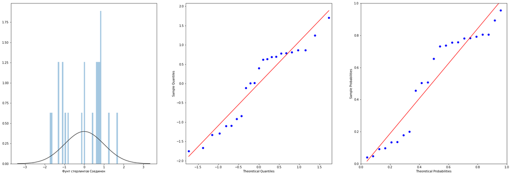

```python
# Стандартизация данных для нормальной отрисовки Q-Q plot
scaler = StandardScaler()
for col in data.columns:
  data[col] = scaler.fit_transform(data[col].values.reshape(-1, 1))


def plots(x):
  fig = plt.figure(figsize=(30,10))
  ax_1 = fig.add_subplot(1, 3, 1)
  ax_2 = fig.add_subplot(1, 3, 2)
  ax_3 = fig.add_subplot(1, 3, 3)

  # distribution plot
  fig1 = sns.distplot(x, fit=stats.norm, kde=False,bins=50, ax=ax_1)
  # Q-Q
  pplot = sm.ProbPlot(x)
  fig2 = pplot.qqplot(line="r", ax=ax_2)

  # P-P
  pplot = sm.ProbPlot(x)
  fig3 = pplot.ppplot(line="r", ax=ax_3)
  plt.show()

for col in data.columns:
  plots(data[col])
```

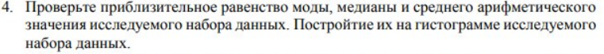

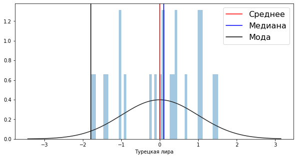

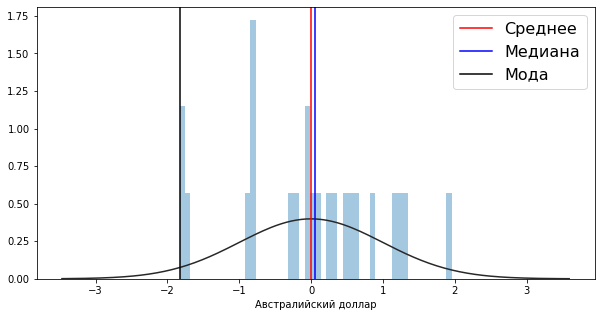

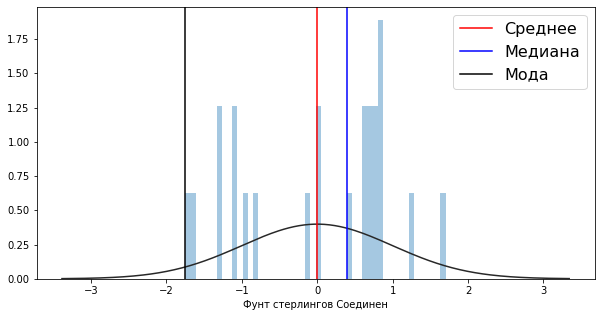

```python
def central_stat(x):
  plt.figure(figsize=(10,5))

  sns.distplot(x, fit=stats.norm, kde=False, bins=50)

  plt.axvline(st.mean(x), 0, 1, label='Среднее', color='red')
  plt.axvline(st.median(x), 0, 1, label='Медиана', color='blue')
  plt.axvline(stats.mode(x)[0], 0, 1, label='Мода', color='black')

  plt.legend(fontsize=16)
  plt.show()

for col in data.columns:
    central_stat(data[col])
```

```python
def print_info(x):
  print("---------",x.to_frame().columns[0],"---------")
  print("Среднее: ", st.mean(x))
  print("Медиана: ", st.median(x))
  print("Мода: ", stats.mode(x)[0])
  print("\n")

for col in data.columns:
    print_info(data[col])
```

```
--------- Турецкая лира ---------
Среднее:  -1.779977131871854e-17
Медиана:  0.0999649713536004
Мода:  [-1.79391434]


--------- Австралийский доллар ---------
Среднее:  -2.6381372931615983e-15
Медиана:  0.05739556646127406
Мода:  [-1.8293612]


--------- Фунт стерлингов Соединен ---------
Среднее:  5.736692823675388e-15
Медиана:  0.3997087210664051
Мода:  [-1.74762859]
```

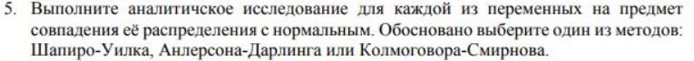

```python
def create_norm(x):
  loc, scale = stats.norm.fit(x)
  n = stats.norm(loc=loc, scale=scale)
  return n

for col in data.columns:
    print("---------",data[col].to_frame().columns[0],"---------")
    print("Тест Калмогорова-Смирнова для RUB:", stats.kstest(data[col], create_norm(data[col]).cdf))
    print("Тест Андерсона-Дарлинга для RUB:", stats.anderson(data[col], 'norm'))
    print("Тест Шапиро-Уилка для RUB:", stats.shapiro(data[col]), "\n")
```

```
--------- Турецкая лира ---------
Тест Калмогорова-Смирнова для RUB: KstestResult(statistic=0.12165634676229747, pvalue=0.8854169522551085)
Тест Андерсона-Дарлинга для RUB: AndersonResult(statistic=0.4773234809267777, critical_values=array([0.511, 0.582, 0.699, 0.815, 0.969]), significance_level=array([15. , 10. ,  5. ,  2.5,  1. ]))
Тест Шапиро-Уилка для RUB: (0.939039409160614, 0.17137333750724792)

--------- Австралийский доллар ---------
Тест Калмогорова-Смирнова для RUB: KstestResult(statistic=0.093590218102506, pvalue=0.9877689715461164)
Тест Андерсона-Дарлинга для RUB: AndersonResult(statistic=0.2530211032583658, critical_values=array([0.511, 0.582, 0.699, 0.815, 0.969]), significance_level=array([15. , 10. ,  5. ,  2.5,  1. ]))
Тест Шапиро-Уилка для RUB: (0.9678516983985901, 0.6377280354499817)

--------- Фунт стерлингов Соединен ---------
Тест Калмогорова-Смирнова для RUB: KstestResult(statistic=0.2106625504164541, pvalue=0.22528791964027461)
Тест Андерсона-Дарлинга для RUB: AndersonResult(statistic=0.976213072142027, critical_values=array([0.511, 0.582, 0.699, 0.815, 0.969]), significance_level=array([15. , 10. ,  5. ,  2.5,  1. ]))
Тест Шапиро-Уилка для RUB: (0.907730758190155, 0.036599431186914444)
```

```
------------------------------------------------------- Турецкая лира ----------------------------------------------------------
```

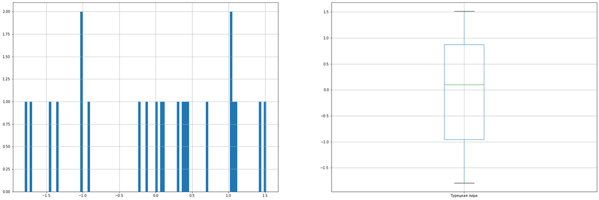

```
------------------------------------------------------- Австралийский доллар ----------------------------------------------------------
```

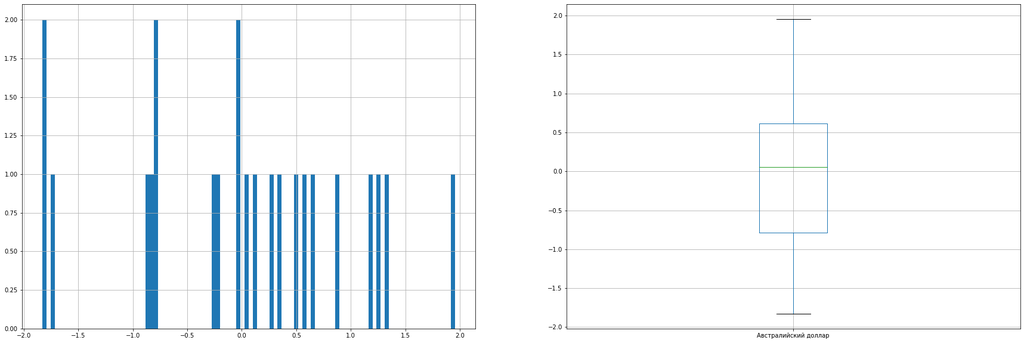

```
------------------------------------------------------- Фунт стерлингов Соединен ----------------------------------------------------------
```

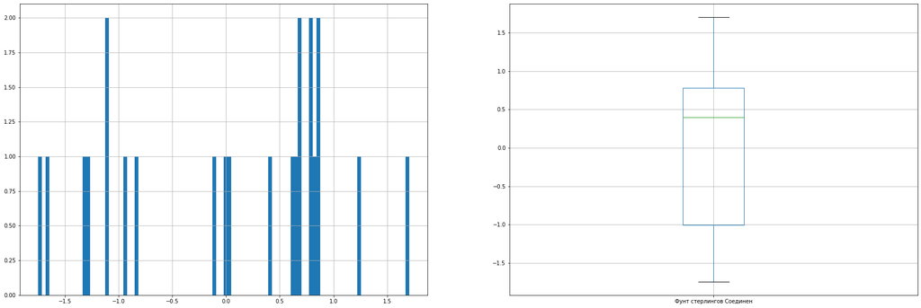

```python
def noize(x):
  fig = plt.figure(figsize=(30,10))
  ax_1 = fig.add_subplot(1, 2, 1)
  ax_2 = fig.add_subplot(1, 2, 2)

  data[x].hist(bins=100, ax=ax_1)
  data.boxplot(column=[x], ax=ax_2)
  plt.show()

for col in data.columns:

  print("-------------------------------------------------------", col, "----------------------------------------------------------\n")
  noize(col)
  print("\n")
```

```python
print("-------Грязные данные-------")
print(data.describe())

def crop(df, column, left=0.05, right=0.95):
    left = df[column].quantile(left)
    right = df[column].quantile(right)
    return df[(df[column] > left) & (df[column] < right)].copy(deep=True)

for col in data.columns:
  data = crop(data, col)

print("\n-------Чистые данные-------")
print(data.describe())
```

```
-------Грязные данные-------
       Турецкая лира  Австралийский доллар  Фунт стерлингов Соединен
count   2.300000e+01          2.300000e+01              2.300000e+01
mean   -9.654113e-18         -2.616265e-15              5.700754e-15
std     1.022475e+00          1.022475e+00              1.022475e+00
min    -1.793914e+00         -1.829361e+00             -1.747629e+00
25%    -9.537963e-01         -7.854218e-01             -1.008079e+00
50%     9.996497e-02          5.739557e-02              3.997087e-01
75%     8.718559e-01          6.129567e-01              7.808659e-01
max     1.515460e+00          1.956104e+00              1.704940e+00

-------Чистые данные-------
       Турецкая лира  Австралийский доллар  Фунт стерлингов Соединен
count      15.000000             15.000000                 15.000000
mean       -0.112772             -0.009292                  0.033192
std         0.845588              0.788702                  0.890661
min        -1.439625             -1.725386                 -1.329799
25%        -0.953796             -0.527019                 -0.969286
50%         0.068309              0.057396                  0.620093
75%         0.417250              0.534847                  0.736179
max         1.109277              1.269762                  0.862138
```

```python
for col in data.columns:
    print("---------",data[col].to_frame().columns[0],"---------")
    print("Тест Калмогорова-Смирнова для RUB:", stats.kstest(data[col], create_norm(data[col]).cdf))
    print("Тест Андерсона-Дарлинга для RUB:", stats.anderson(data[col], 'norm'))
    print("Тест Шапиро-Уилка для RUB:", stats.shapiro(data[col]), "\n")
```

```
--------- Турецкая лира ---------
Тест Калмогорова-Смирнова для RUB: KstestResult(statistic=0.16730258667383247, pvalue=0.778253821037589)
Тест Андерсона-Дарлинга для RUB: AndersonResult(statistic=0.4288774630278951, critical_values=array([0.498, 0.568, 0.681, 0.794, 0.945]), significance_level=array([15. , 10. ,  5. ,  2.5,  1. ]))
Тест Шапиро-Уилка для RUB: (0.9281125664710999, 0.25566890835762024)

--------- Австралийский доллар ---------
Тест Калмогорова-Смирнова для RUB: KstestResult(statistic=0.11228345400742634, pvalue=0.9915361617310174)
Тест Андерсона-Дарлинга для RUB: AndersonResult(statistic=0.23022541407231856, critical_values=array([0.498, 0.568, 0.681, 0.794, 0.945]), significance_level=array([15. , 10. ,  5. ,  2.5,  1. ]))
Тест Шапиро-Уилка для RUB: (0.9696488976478577, 0.852821409702301)

--------- Фунт стерлингов Соединен ---------
Тест Калмогорова-Смирнова для RUB: KstestResult(statistic=0.2857385205353574, pvalue=0.14103378654906656)
Тест Андерсона-Дарлинга для RUB: AndersonResult(statistic=1.4498143297133517, critical_values=array([0.498, 0.568, 0.681, 0.794, 0.945]), significance_level=array([15. , 10. ,  5. ,  2.5,  1. ]))
Тест Шапиро-Уилка для RUB: (0.7772397398948669, 0.001904256409034133)
```

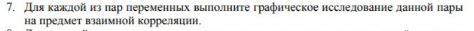

```
--Корреляционная матрица--
                           Турецкая лира  ...  Фунт стерлингов Соединен
Турецкая лира                  1.000000  ...                 -0.200866
Австралийский доллар           0.017039  ...                  0.732883
Фунт стерлингов Соединен      -0.200866  ...                  1.000000

[3 rows x 3 columns]
--------------------------
```

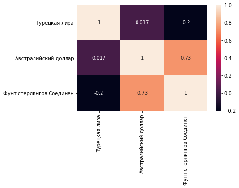

```python
sns.heatmap(data.corr(), annot=True)
print("\n--Корреляционная матрица--\n", data.corr(), "\n--------------------------")
```

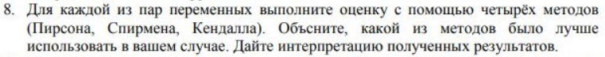

```python
def show_criteria(label, method, x, y):
  criteria_val, criteria_p = method(data[x],data[y])
  print(label, " R =", criteria_val, "    | p= ", criteria_p)

for ind1 in range(len(data.columns)):
  if (ind1 == len(data.columns)-1):
    ind2 = 0
  else:
    ind2 = ind1 + 1
  print("--", data.columns[ind1], "--", data.columns[ind2], "--")
  show_criteria("Kendall correlation: ", stats.kendalltau, data.columns[ind1], data.columns[ind2])
  show_criteria("Pearson correlation: ", stats.pearsonr, data.columns[ind1], data.columns[ind2])
  show_criteria("Spearman correlation: ", stats.spearmanr, data.columns[ind1], data.columns[ind2])
  print("\n")
```

```
-- Турецкая лира -- Австралийский доллар --
Kendall correlation:   R = 0.028571428571428574     | p=  0.9225700904951897
Pearson correlation:   R = 0.01703918050447136     | p=  0.9519397896965863
Spearman correlation:   R = 0.075     | p=  0.7905107941552679


-- Австралийский доллар -- Фунт стерлингов Соединен --
Kendall correlation:   R = 0.5428571428571429     | p=  0.00414288160001619
Pearson correlation:   R = 0.7328827797801759     | p=  0.001882579702155048
Spearman correlation:   R = 0.6785714285714285     | p=  0.005416550219591705


-- Фунт стерлингов Соединен -- Турецкая лира --
Kendall correlation:   R = 0.06666666666666668     | p=  0.770495669755301
Pearson correlation:   R = -0.20086609536500338     | p=  0.47286324873344665
Spearman correlation:   R = -0.014285714285714282     | p=  0.9596997645989476
```

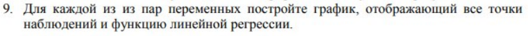

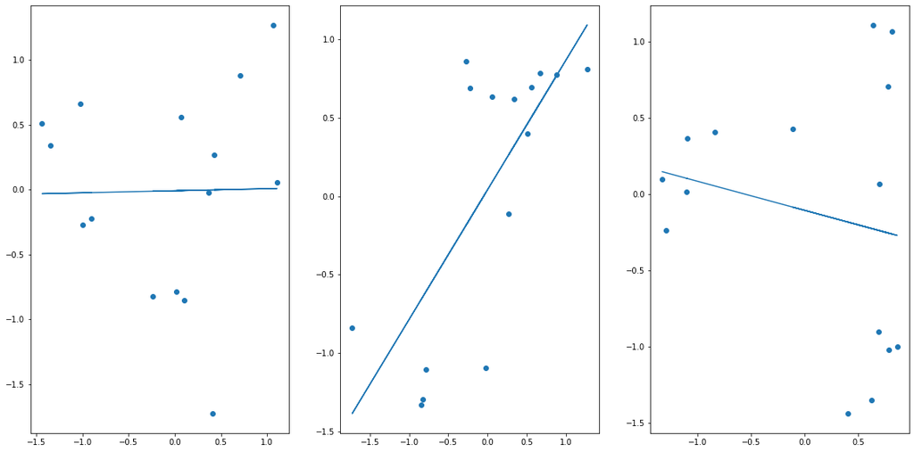

```python
def show_regression(x, y, axis):
  axis.scatter(data[x] ,data[y])
  m, b = np. polyfit(data[x], data[y], 1)
  axis.plot(data[x], m*data[x]+b)

fig, ax = plt.subplots(1, len(data.columns), figsize=(20,10))


for ind1 in range(len(data.columns)):
  if (ind1 == len(data.columns)-1):
    ind2 = 0
  else:
    ind2 = ind1 + 1
  show_regression( data.columns[ind1], data.columns[ind2], ax[ind1])
```

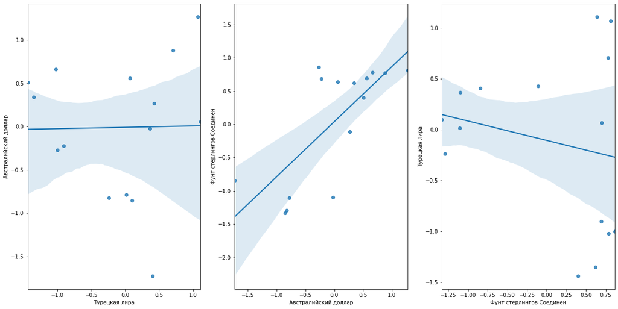

```python
fig, ax = plt.subplots(1, len(data.columns), figsize=(20,10))

for ind1 in range(len(data.columns)):
  if (ind1 == len(data.columns)-1):
    ind2 = 0
  else:
    ind2 = ind1 + 1
  sns.regplot(data.columns[ind1], data.columns[ind2], data, ax=ax[ind1])
```